# Machine Learning Workflow: SVM with Polynomial Kernel (Heart Data)

Biostat 212A

Author

Dr. Jin Zhou @ UCLA

Published

March 8, 2025

**R**

## 1 Overview

[figure not shown]

We illustrate the typical machine learning workflow for support vector machines using the `Heart` data set. The outcome is `AHD` (`Yes` or `No`).

1. Initial splitting to test and non-test sets.
2. Pre-processing of data: dummy coding categorical variables, standardizing numerical variables, imputing missing values, …
3. Tune the SVM algorithm using 5-fold cross-validation (CV) on the non-test data.
4. Choose the best model by CV and refit it on the whole non-test data.
5. Final classification on the test data.

## 2 Heart data

The goal is to predict the binary outcome `AHD` (`Yes` or `No`) of patients.

**R**

```r
# Load libraries
library(GGally)
library(gtsummary)
library(kernlab)
library(tidyverse)
library(tidymodels)

# Load the `Heart.csv` data.
Heart <- read_csv("../data/Heart.csv") %>%
  # first column is patient ID, which we don't need
  select(-1) %>%
  # RestECG is categorical with value 0, 1, 2
  mutate(RestECG = as.character(RestECG)) %>%
  print(width = Inf)
```

```
# A tibble: 303 × 14
     Age   Sex ChestPain    RestBP  Chol   Fbs RestECG MaxHR ExAng Oldpeak Slope
   <dbl> <dbl> <chr>         <dbl> <dbl> <dbl> <chr>   <dbl> <dbl>   <dbl> <dbl>
 1    63     1 typical         145   233     1 2         150     0     2.3     3
 2    67     1 asymptomatic    160   286     0 2         108     1     1.5     2
 3    67     1 asymptomatic    120   229     0 2         129     1     2.6     2
 4    37     1 nonanginal      130   250     0 0         187     0     3.5     3
 5    41     0 nontypical      130   204     0 2         172     0     1.4     1
 6    56     1 nontypical      120   236     0 0         178     0     0.8     1
 7    62     0 asymptomatic    140   268     0 2         160     0     3.6     3
 8    57     0 asymptomatic    120   354     0 0         163     1     0.6     1
 9    63     1 asymptomatic    130   254     0 2         147     0     1.4     2
10    53     1 asymptomatic    140   203     1 2         155     1     3.1     3
      Ca Thal       AHD
   <dbl> <chr>      <chr>
 1     0 fixed      No
 2     3 normal     Yes
 3     2 reversable Yes
 4     0 normal     No
 5     0 normal     No
 6     0 normal     No
 7     2 normal     Yes
 8     0 normal     No
 9     1 reversable Yes
10     0 reversable Yes
# ℹ 293 more rows
```

```r
# Numerical summaries stratified by the outcome `AHD`.
Heart %>% tbl_summary(by = AHD)
```

| **Characteristic** | **No** N = 164<sup>1</sup> | **Yes** N = 139<sup>1</sup> |
| --- | --- | --- |
| Age | 52 (45, 59) | 58 (52, 62) |
| Sex | 92 (56%) | 114 (82%) |
| ChestPain |  |  |
| asymptomatic | 39 (24%) | 105 (76%) |
| nonanginal | 68 (41%) | 18 (13%) |
| nontypical | 41 (25%) | 9 (6.5%) |
| typical | 16 (9.8%) | 7 (5.0%) |
| RestBP | 130 (120, 140) | 130 (120, 145) |
| Chol | 235 (209, 268) | 249 (217, 284) |
| Fbs | 23 (14%) | 22 (16%) |
| RestECG |  |  |
| 0 | 95 (58%) | 56 (40%) |
| 1 | 1 (0.6%) | 3 (2.2%) |
| 2 | 68 (41%) | 80 (58%) |
| MaxHR | 161 (149, 172) | 142 (125, 157) |
| ExAng | 23 (14%) | 76 (55%) |
| Oldpeak | 0.20 (0.00, 1.05) | 1.40 (0.50, 2.50) |
| Slope |  |  |
| 1 | 106 (65%) | 36 (26%) |
| 2 | 49 (30%) | 91 (65%) |
| 3 | 9 (5.5%) | 12 (8.6%) |
| Ca |  |  |
| 0 | 130 (81%) | 46 (33%) |
| 1 | 21 (13%) | 44 (32%) |
| 2 | 7 (4.3%) | 31 (22%) |
| 3 | 3 (1.9%) | 17 (12%) |
| Unknown | 3 | 1 |
| Thal |  |  |
| fixed | 6 (3.7%) | 12 (8.7%) |
| normal | 129 (79%) | 37 (27%) |
| reversable | 28 (17%) | 89 (64%) |
| Unknown | 1 | 1 |

<sup>1</sup> Median (Q1, Q3); n (%)

```r
# Graphical summary:
# Heart %>% ggpairs()
```

## 3 Initial split into test and non-test sets

We randomly split the data into 25% test data and 75% non-test data. Stratify on `AHD`.

**R**

```r
# For reproducibility
set.seed(203)

data_split <- initial_split(
  Heart,
  # stratify by AHD
  strata = "AHD",
  prop = 0.75
  )
data_split
```

```
<Training/Testing/Total>
<227/76/303>
```

```r
Heart_other <- training(data_split)
dim(Heart_other)
```

```
[1] 227  14
```

```r
Heart_test <- testing(data_split)
dim(Heart_test)
```

```
[1] 76 14
```

## 4 Recipe (R) and Preprocessing (Python)

- A data dictionary (roughly) is at https://keras.io/examples/structured_data/structured_data_classification_with_feature_space/.
- We have following features:
  - Numerical features: `Age`, `RestBP`, `Chol`, `Slope` (1, 2 or 3), `MaxHR`, `ExAng`, `Oldpeak`, `Ca` (0, 1, 2 or 3).
  - Categorical features coded as integer: `Sex` (0 or 1), `Fbs` (0 or 1), `RestECG` (0, 1 or 2).
  - Categorical features coded as string: `ChestPain`, `Thal`.
- There are missing values in `Ca` and `Thal`. Since missing proportion is not high, we will use simple mean (for numerical feature `Ca`) and mode (for categorical feature `Thal`) imputation.

**R**

```r
svm_recipe <-
  recipe(
    AHD ~ .,
    data = Heart_other
  ) %>%
  # mean imputation for Ca
  step_impute_mean(Ca) %>%
  # mode imputation for Thal
  step_impute_mode(Thal) %>%
  # create traditional dummy variables (necessary for svm)
  step_dummy(all_nominal_predictors()) %>%
  # zero-variance filter
  step_zv(all_numeric_predictors()) %>%
  # center and scale numeric data
  step_normalize(all_numeric_predictors()) # %>%
  # estimate the means and standard deviations
  # prep(training = Heart_other, retain = TRUE)
svm_recipe
```

[output not shown]

## 5 Model

**R**

```r
svm_mod <-
  svm_poly(
    mode = "classification",
    cost = tune(),
    degree = tune(),
    # scale_factor = tune()
  ) %>%
  set_engine("kernlab")
svm_mod
```

```
Polynomial Support Vector Machine Model Specification (classification)

Main Arguments:
  cost = tune()
  degree = tune()

Computational engine: kernlab
```

## 6 Workflow in R and pipeline in Python

Here we bundle the preprocessing step (Python) or recipe (R) and model.

**R**

```r
svm_wf <- workflow() %>%
  add_recipe(svm_recipe) %>%
  add_model(svm_mod)
svm_wf
```

```
══ Workflow ════════════════════════════════════════════════════════════════════
Preprocessor: Recipe
Model: svm_poly()

── Preprocessor ────────────────────────────────────────────────────────────────
5 Recipe Steps

• step_impute_mean()
• step_impute_mode()
• step_dummy()
• step_zv()
• step_normalize()

── Model ───────────────────────────────────────────────────────────────────────
Polynomial Support Vector Machine Model Specification (classification)

Main Arguments:
  cost = tune()
  degree = tune()

Computational engine: kernlab
```

## 7 Tuning grid

**R**

```r
param_grid <- grid_regular(
  cost(range = c(-3, 2)),
  degree(range = c(1, 5)),
  #scale_factor(range = c(-1, 1)),
  levels = c(5)
  )
param_grid
```

```
# A tibble: 25 × 2
    cost degree
   <dbl>  <dbl>
 1 0.125      1
 2 0.297      1
 3 0.707      1
 4 1.68       1
 5 4          1
 6 0.125      2
 7 0.297      2
 8 0.707      2
 9 1.68       2
10 4          2
# ℹ 15 more rows
```

## 8 Cross-validation (CV)

**R**

Set cross-validation partitions.

```r
set.seed(203)

folds <- vfold_cv(Heart_other, v = 5)
folds
```

```
#  5-fold cross-validation
# A tibble: 5 × 2
  splits           id
  <list>           <chr>
1 <split [181/46]> Fold1
2 <split [181/46]> Fold2
3 <split [182/45]> Fold3
4 <split [182/45]> Fold4
5 <split [182/45]> Fold5
```

Fit cross-validation.

```r
svm_fit <- svm_wf %>%
  tune_grid(
    resamples = folds,
    grid = param_grid,
    metrics = metric_set(roc_auc, accuracy)
    )
svm_fit
```

```
# Tuning results
# 5-fold cross-validation
# A tibble: 5 × 4
  splits           id    .metrics          .notes
  <list>           <chr> <list>            <list>
1 <split [181/46]> Fold1 <tibble [50 × 6]> <tibble [0 × 3]>
2 <split [181/46]> Fold2 <tibble [50 × 6]> <tibble [0 × 3]>
3 <split [182/45]> Fold3 <tibble [50 × 6]> <tibble [0 × 3]>
4 <split [182/45]> Fold4 <tibble [50 × 6]> <tibble [0 × 3]>
5 <split [182/45]> Fold5 <tibble [50 × 6]> <tibble [0 × 3]>
```

Visualize CV results:

```
# A tibble: 50 × 8
    cost degree .metric  .estimator  mean     n std_err .config
   <dbl>  <dbl> <chr>    <chr>      <dbl> <int>   <dbl> <chr>
 1 0.125      1 accuracy binary     0.828     5 0.0187  Preprocessor1_Model01
 2 0.125      1 roc_auc  binary     0.911     5 0.00945 Preprocessor1_Model01
 3 0.297      1 accuracy binary     0.833     5 0.0203  Preprocessor1_Model02
 4 0.297      1 roc_auc  binary     0.912     5 0.0124  Preprocessor1_Model02
 5 0.707      1 accuracy binary     0.833     5 0.0254  Preprocessor1_Model03
 6 0.707      1 roc_auc  binary     0.917     5 0.0110  Preprocessor1_Model03
 7 1.68       1 accuracy binary     0.824     5 0.0301  Preprocessor1_Model04
 8 1.68       1 roc_auc  binary     0.915     5 0.0118  Preprocessor1_Model04
 9 4          1 accuracy binary     0.833     5 0.0273  Preprocessor1_Model05
10 4          1 roc_auc  binary     0.917     5 0.0119  Preprocessor1_Model05
# ℹ 40 more rows
```

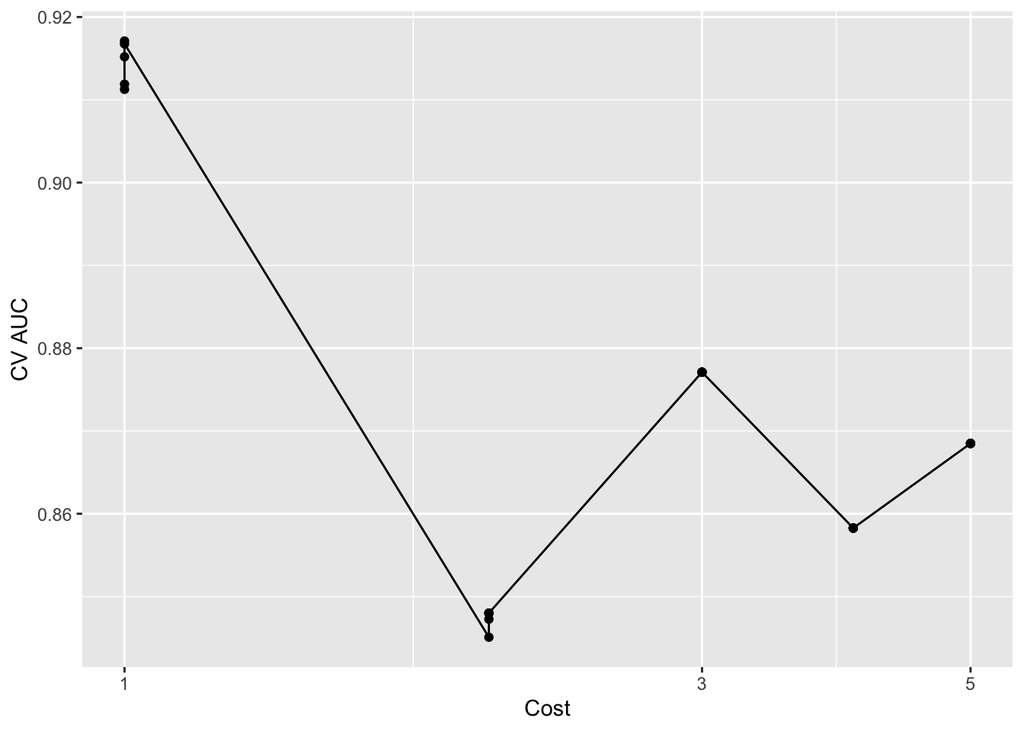

```r
svm_fit %>%
  collect_metrics() %>%
  print(width = Inf) %>%
  filter(.metric == "roc_auc" ) %>%
  ggplot(mapping = aes(x = degree, y = mean)) +
  geom_point() +
  geom_line() +
  labs(x = "Cost", y = "CV AUC") +
  scale_x_log10()
```

Show the top 5 models.

```r
svm_fit %>%
  show_best(metric = "roc_auc")
```

```
# A tibble: 5 × 8
   cost degree .metric .estimator  mean     n std_err .config
  <dbl>  <dbl> <chr>   <chr>      <dbl> <int>   <dbl> <chr>
1 0.707      1 roc_auc binary     0.917     5 0.0110  Preprocessor1_Model03
2 4          1 roc_auc binary     0.917     5 0.0119  Preprocessor1_Model05
3 1.68       1 roc_auc binary     0.915     5 0.0118  Preprocessor1_Model04
4 0.297      1 roc_auc binary     0.912     5 0.0124  Preprocessor1_Model02
5 0.125      1 roc_auc binary     0.911     5 0.00945 Preprocessor1_Model01
```

Let’s select the best model.

```r
best_svm <- svm_fit %>%
  select_best(metric ="roc_auc")
best_svm
```

```
# A tibble: 1 × 3
   cost degree .config
  <dbl>  <dbl> <chr>
1 0.707      1 Preprocessor1_Model03
```

## 9 Finalize our model

Now we are done tuning. Finally, let’s fit this final model to the whole training data and use our test data to estimate the model performance we expect to see with new data.

**R**

```r
# Final workflow
final_wf <- svm_wf %>%
  finalize_workflow(best_svm)
final_wf
```

```
══ Workflow ════════════════════════════════════════════════════════════════════
Preprocessor: Recipe
Model: svm_poly()

── Preprocessor ────────────────────────────────────────────────────────────────
5 Recipe Steps

• step_impute_mean()
• step_impute_mode()
• step_dummy()
• step_zv()
• step_normalize()

── Model ───────────────────────────────────────────────────────────────────────
Polynomial Support Vector Machine Model Specification (classification)

Main Arguments:
  cost = 0.707106781186548
  degree = 1

Computational engine: kernlab
```

```r
# Fit the whole training set, then predict the test cases
final_fit <-
  final_wf %>%
  last_fit(data_split)
final_fit
```

```
# Resampling results
# Manual resampling
# A tibble: 1 × 6
  splits           id               .metrics .notes   .predictions .workflow
  <list>           <chr>            <list>   <list>   <list>       <list>
1 <split [227/76]> train/test split <tibble> <tibble> <tibble>     <workflow>
```

```r
# Test metrics
final_fit %>%
  collect_metrics()
```

```
# A tibble: 3 × 4
  .metric     .estimator .estimate .config
  <chr>       <chr>          <dbl> <chr>
1 accuracy    binary         0.789 Preprocessor1_Model1
2 roc_auc     binary         0.860 Preprocessor1_Model1
3 brier_class binary         0.157 Preprocessor1_Model1
```

```r
library(doParallel)
set.seed(101)
split_obj <- initial_split(data = Heart, prop = 0.7, strata = AHD)
train <- training(split_obj)
test <- testing(split_obj)


# Create the recipe
recipe(AHD ~ ., data = train) %>%
  # mean imputation for Ca
  step_impute_mean(Ca) %>%
  # mode imputation for Thal
  step_impute_mode(Thal) %>%
  # create traditional dummy variables (necessary for svm)
  step_dummy(all_nominal_predictors()) %>%
  # zero-variance filter
  step_zv(all_numeric_predictors()) %>%
  # center and scale numeric data
  step_normalize(all_numeric_predictors()) %>%
  # estimate the means and standard deviations
  prep() -> recipe_obj

# Bake
train <- bake(recipe_obj, new_data=train)
test <- bake(recipe_obj, new_data=test)
```

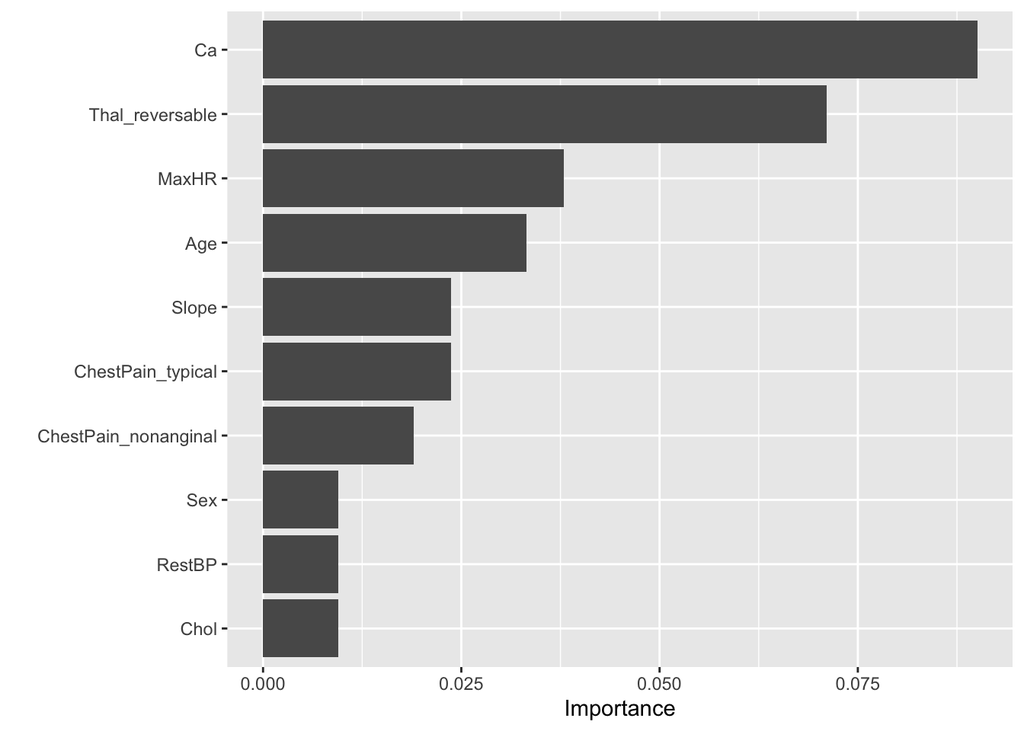

```r
library(vip)
final_fit %>%
  pluck(".workflow", 1) %>%
  pull_workflow_fit() %>%
  # vip(method = "permute", train= Heart)
  vip(method = "permute",
      target = "AHD", metric = "accuracy",
      pred_wrapper = kernlab::predict, train = train)
```

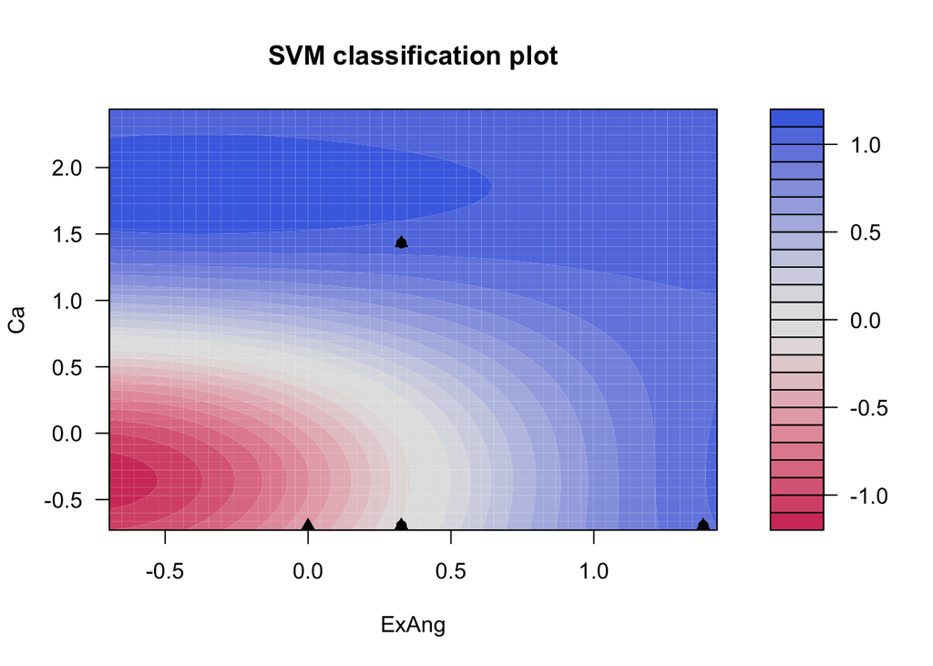

```r
svm_rbf_spec <- svm_rbf() %>%
  set_mode("classification") %>%
  set_engine("kernlab")

svm_rbf_fit <- svm_rbf_spec %>%
  fit(AHD ~ ., data = train[, c('Ca', 'ExAng', 'AHD')])

svm_rbf_fit %>%
  extract_fit_engine() %>%
  plot()
```